# 648 Lab 4

gucci fan

2024-11-14

```r
library(tidytext)
library(textdata)
library(tidyverse)
```

I am choosing to perform a sentiment analysis on an album entitled “The Head Hurts but the Heart Knows the Truth” by musical artist Headache, released in May 2023. The genre is dance/electronic but the lyrics are spoken text narrating a long, rambling, somewhat confusing stream of consciousness of an individual reflecting on their life, love, and loneliness. To me (a human), it sounds very unsettling, perhaps sad, but definitely negative. Online, there has been discourse about the origin of the lyrics - some people think they were generated and/or performed by AI.

```r
headache_raw <- read.csv("headache-album.csv")
nrc_sentiments <- get_sentiments("nrc")
unique_sentiments <- unique(nrc_sentiments$sentiment)
print(unique_sentiments)
```

```
##  [1] "trust"        "fear"         "negative"     "sadness"      "anger"
##  [6] "surprise"     "positive"     "disgust"      "joy"          "anticipation"
```

I loaded the album lyrics into a CSV file line by line for each track, and am reading them in here. I am using the NRC sentiment analysis to analyze with multiple sentiment/feeling types.

```r
library(stringr)
headache_raw$lyric <- as.character(headache_raw$lyric)

tidy_song <- headache_raw %>%
  group_by(track_title) %>%
  ungroup() %>%
  unnest_tokens(word,lyric)

head(tidy_song)
```

```
## # A tibble: 6 × 5
##       X track_title              track_n  line word
##   <int> <chr>                      <int> <int> <chr>
## 1     1 The Beginning of the End       1     1 have
## 2     1 The Beginning of the End       1     1 you
## 3     1 The Beginning of the End       1     1 ever
## 4     1 The Beginning of the End       1     1 woken
## 5     1 The Beginning of the End       1     1 up
## 6     1 The Beginning of the End       1     1 and
```

I am splitting each line of lyric into individual words while keeping track of what track they belong to.

```r
headache_with_sentiment <- tidy_song %>% left_join(nrc_sentiments, by="word", relationship="many-to-many")
headache_sentiment_filtered <- headache_with_sentiment %>% filter(!is.na(sentiment))
print(headache_sentiment_filtered)
```

```
## # A tibble: 828 × 6
##        X track_title              track_n  line word      sentiment
##    <int> <chr>                      <int> <int> <chr>     <chr>
##  1     3 The Beginning of the End       1     3 headache  negative
##  2     4 The Beginning of the End       1     4 breakfast positive
##  3    11 The Beginning of the End       1    11 time      anticipation
##  4    11 The Beginning of the End       1    11 good      anticipation
##  5    11 The Beginning of the End       1    11 good      joy
##  6    11 The Beginning of the End       1    11 good      positive
##  7    11 The Beginning of the End       1    11 good      surprise
##  8    11 The Beginning of the End       1    11 good      trust
##  9    16 The Beginning of the End       1    16 job       positive
## 10    17 The Beginning of the End       1    17 job       positive
## # ℹ 818 more rows
```

Now I am doing a left join with nrc sentiments to apply sentiments, where available, to the lyrics. However, a lot of the words return as NA because no sentiment is found, so I dropped the NA words. Also, I decided to allow a many to many relationship to encompass all of the available sentiments - sometimes a single word has multiple associated sentiments. For example the word “good” can be anticipation, joy, positive, surprise, and trust.

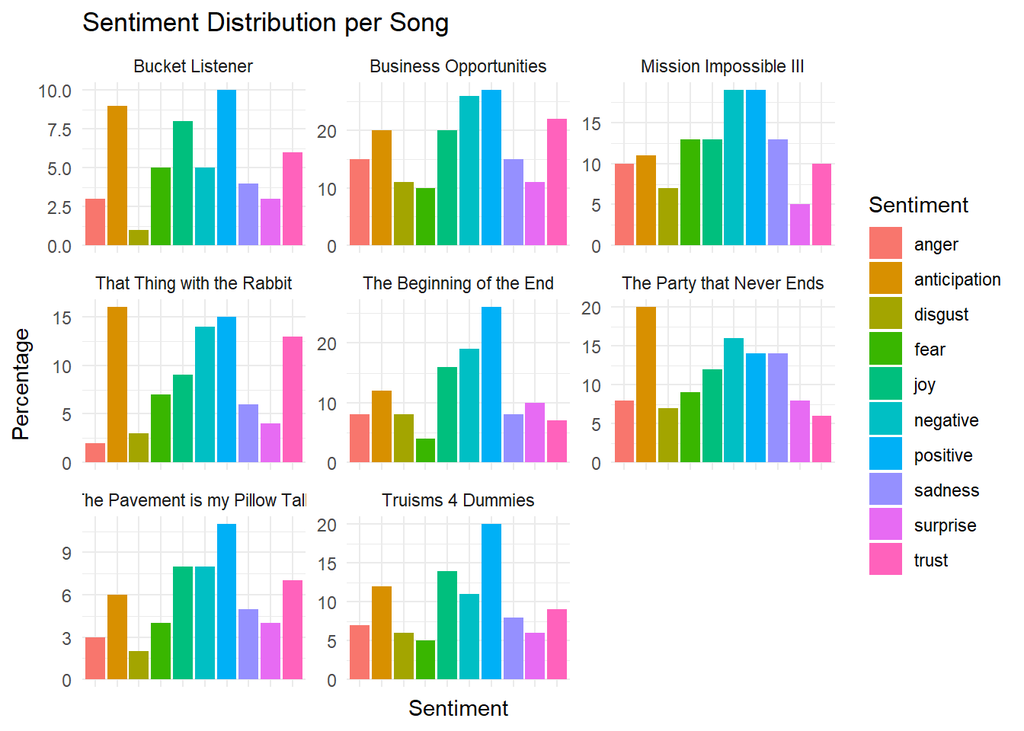

```r
sentiment_counts <- headache_sentiment_filtered %>%
   count(track_title, sentiment) #%>%
  # complete(track_title, sentiment, fill = list(n = 0))

sentiment_counts <- sentiment_counts %>%
  group_by(track_title) %>%
  mutate(percentage = n / sum(n),
         label = scales::percent(percentage, accuracy = 1)) %>%
  ungroup()

# ggplot(sentiment_counts, aes("", n, fill = sentiment)) +
#   geom_bar(stat = "identity", width = 1) +
#     geom_text(aes(label = label),
#             position = position_stack(vjust = 0.5),
#             size = 3) +
#   coord_polar("y") +
#   facet_wrap(~ track_title) +
#   labs(title = "Sentiment Distribution per Song",
#        fill = "Sentiment") +
#   theme_void()

# ggplot(sentiment_counts, aes("", n, fill = sentiment)) +
#   geom_bar(stat = "identity", width = 1) +
#   geom_text(aes(label = ifelse(percentage > 0.05, label, "")),
#             position = position_stack(vjust = 0.5),
#             size = 3) +
#   coord_polar("y") +
#   facet_wrap(~ track_title) +
#   labs(title = "Sentiment Distribution per Song",
#        fill = "Sentiment") +
#   theme_void()

ggplot(sentiment_counts, aes(x = sentiment, y = n, fill = sentiment)) +
  geom_bar(stat = "identity", position = "dodge") +
  facet_wrap(~ track_title, scales = "free_y") +
  labs(title = "Sentiment Distribution per Song",
       x = "Sentiment",
       y = "Percentage",
       fill = "Sentiment") +
  theme_minimal() +
  theme(axis.text.x = element_blank())
```

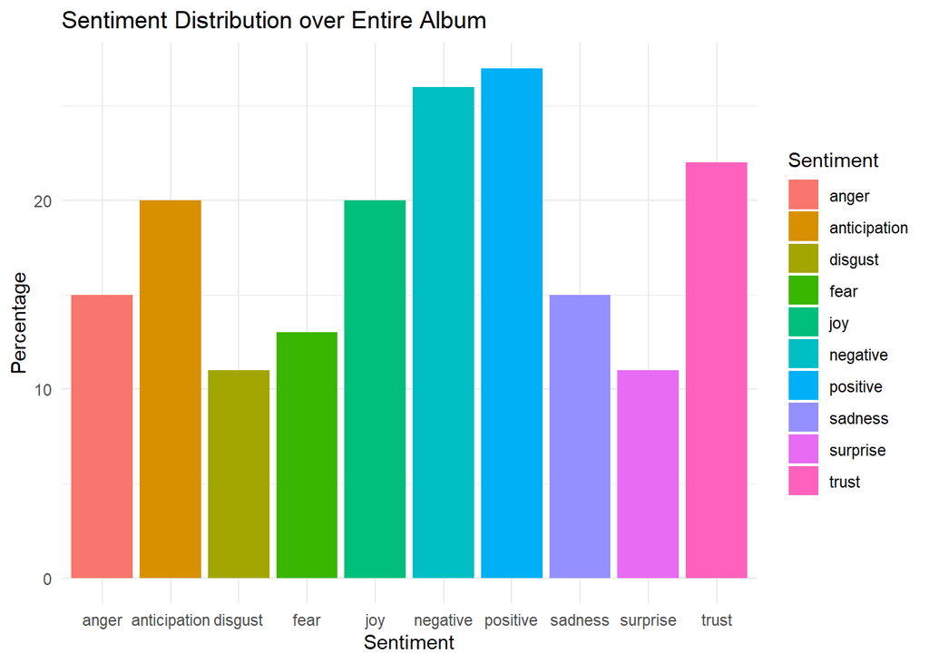

```r
ggplot(sentiment_counts, aes(x = sentiment, y = n, fill = sentiment)) +
  geom_bar(stat = "identity", position = "dodge") +
  #facet_wrap(~ track_title, scales = "free_y") +
  labs(title = "Sentiment Distribution over Entire Album",
       x = "Sentiment",
       y = "Percentage",
       fill = "Sentiment") +
  theme_minimal()
```

Now I am reproducing these visualizations with afinn.

```r
afinn_sentiments <- get_sentiments("afinn")
headache_sentiment_afinn <- tidy_song %>% left_join(afinn_sentiments, by="word") %>% filter(!is.na(value))
head(headache_sentiment_afinn)
```

```
## # A tibble: 6 × 6
##       X track_title              track_n  line word    value
##   <int> <chr>                      <int> <int> <chr>   <dbl>
## 1     6 The Beginning of the End       1     6 care        2
## 2    11 The Beginning of the End       1    11 good        3
## 3    12 The Beginning of the End       1    12 strange    -1
## 4    15 The Beginning of the End       1    15 better      2
## 5    22 The Beginning of the End       1    22 please      1
## 6    22 The Beginning of the End       1    22 please      1
```

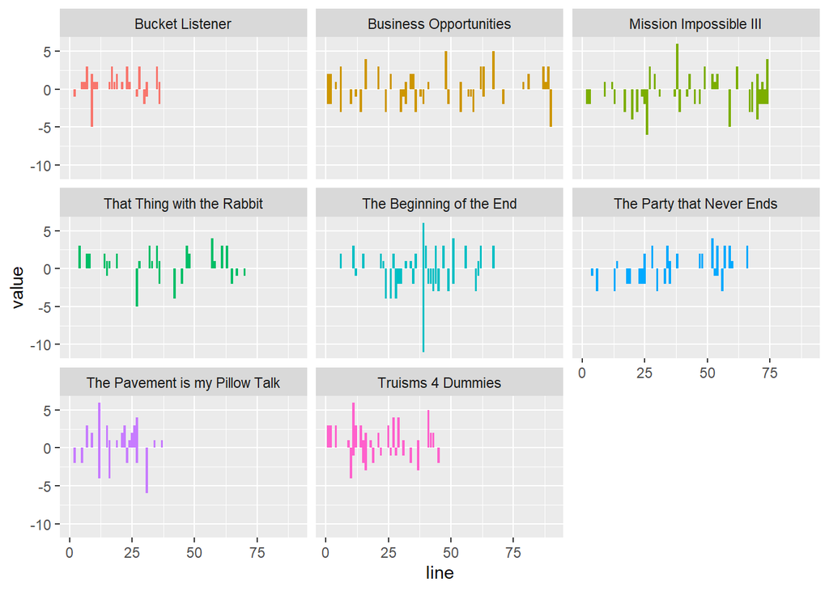

```r
ggplot(headache_sentiment_afinn, aes(line, value, fill = track_title)) +
  geom_col(show.legend = FALSE) +
  facet_wrap(~track_title)
```

From the statement analysis with the afinn lexicon assigning negative and positive numbers to words, there is a slight bit of negative trending especially in the song “The Beginning of the End”. However, overall there is not a strong trend towards either positive or negative sentiment in any of the songs. This is interesting because it shows that just based on words in their raw state, not considering context, this set of words has a somewhat neutral distribution of sentiment.

I asked ChatGPT to perform a sentiment analysis on the album next. I experimented with asking it to use the sentiment lexicons (it gave me a tutorial of how to reproduce the methods in this lab), versus asking for “meanings” and “themes”. This paragraph of its explanation resonated most:

“The album carries a nonlinear narrative structure, presenting fragmented introspections about love, loss, and resilience. Tracks like”Business Opportunities” highlight dark, visceral moments, including a failed suicide attempt, juxtaposed with uplifting segments in later songs like “Truisms 4 Dummies,” suggesting a shift toward optimism. Central to the album is the idea that “love is the only thought and pain is the only feeling,” but this overarching theme invites debate due to its absolutist perspective. The AI voice adds a haunting, otherworldly quality, amplifying the album’s emotional tension and innovation.”

I think this does a good job of summarizing the surface sentiment of the songs, as it is able to take into context the meaning of the lyrics instead of just analyzing each word. It’s probably also subjective how sentiment is perceived and there isn’t a “correct” analysis - one person or AI’s impression could be different than another.